# Homework Assignment 2

Yusuf Uzhunnan

Due Sun Nov 08, 2020 11:59PM

```r
library(dplyr)
```

```r
library("ggplot2")
```

## HW-2 Instructions

Consider yourself on a consulting assignment with the CitiBike program (aka the client). Your client has collected all this data but lack the analytical skills to explore/analyze/visualize the data - particularly because the data is pretty big in size. They have called you because they have heard that you are all experts in R and can make a ham sandwich out of Big Data in no time.

1. Understand the data. Download all the monthly data and combine to create a 2019 year dataset. Explore the dataset to calculate descriptive statistics. Do exploratory visualization to better understand the dataset.
2. Identify patterns in the ride history data. Explain/illustrate these patterns using appropriate visualization. This is purposely open ended. You are expected to pose interesting questions and answer them (e.g. does the ridership pattern differ between weekdays and weekends?)

### Import Data

```r
# Read each Data File into its respective month's variable

January <- read.csv("201901-citibike-tripdata.csv")
February <- read.csv("201902-citibike-tripdata.csv")
March <- read.csv("201903-citibike-tripdata.csv")
April <- read.csv("201904-citibike-tripdata.csv")
May <- read.csv("201905-citibike-tripdata.csv")
June <- read.csv("201906-citibike-tripdata.csv")
July <- read.csv("201907-citibike-tripdata.csv")
August <- read.csv("201908-citibike-tripdata.csv")
September <- read.csv("201909-citibike-tripdata.csv")
October <- read.csv("201910-citibike-tripdata.csv")
November <- read.csv("201911-citibike-tripdata.csv")
December <- read.csv("201912-citibike-tripdata.csv")
```

```r
# Combine into one variable

total2019 <- rbind(January, February, March, April, May, June, July, August, September, October, November, December)

# Take a 5% sample of dataset
usedDataset <- sample_frac(total2019,.05)

# Convert Gender to Factor
usedDataset$gender <- as.factor(usedDataset$gender)
```

### Part 1: Data Exploration

```r
# Summary of Data
summary(usedDataset)
```

```
##   tripduration        starttime           stoptime         start.station.id
##  Min.   :     61.0   Length:1027585     Length:1027585     Length:1027585
##  1st Qu.:    362.0   Class :character   Class :character   Class :character
##  Median :    615.0   Mode  :character   Mode  :character   Mode  :character
##  Mean   :    966.1
##  3rd Qu.:   1079.0
##  Max.   :2754673.0
##  start.station.name start.station.latitude start.station.longitude
##  Length:1027585     Min.   :40.66          Min.   :-74.03
##  Class :character   1st Qu.:40.72          1st Qu.:-74.00
##  Mode  :character   Median :40.74          Median :-73.99
##                     Mean   :40.74          Mean   :-73.98
##                     3rd Qu.:40.76          3rd Qu.:-73.97
##                     Max.   :40.86          Max.   :-73.89
##  end.station.id     end.station.name   end.station.latitude
##  Length:1027585     Length:1027585     Min.   :40.66
##  Class :character   Class :character   1st Qu.:40.72
##  Mode  :character   Mode  :character   Median :40.74
##                                        Mean   :40.74
##                                        3rd Qu.:40.76
##                                        Max.   :40.86
##  end.station.longitude     bikeid        usertype           birth.year
##  Min.   :-74.05        Min.   :14529   Length:1027585     Min.   :1874
##  1st Qu.:-74.00        1st Qu.:25339   Class :character   1st Qu.:1970
##  Median :-73.99        Median :30919   Mode  :character   Median :1983
##  Mean   :-73.98        Mean   :29675                      Mean   :1980
##  3rd Qu.:-73.97        3rd Qu.:35054                      3rd Qu.:1990
##  Max.   :-73.89        Max.   :42046                      Max.   :2003
##  gender
##  0: 78706
##  1:702733
##  2:246146
##
##
##
```

```r
# Structure Data
str(usedDataset)
```

```
## 'data.frame':    1027585 obs. of  15 variables:
##  $ tripduration           : int  1097 352 334 579 1162 616 300 1621 552 419 ...
##  $ starttime              : chr  "2019-09-13 17:28:45.8070" "2019-07-03 17:58:48.5460" "2019-08-08 09:06:16.8690" "2019-01-22 15:59:00.5630" ...
##  $ stoptime               : chr  "2019-09-13 17:47:03.0770" "2019-07-03 18:04:40.7810" "2019-08-08 09:11:51.6850" "2019-01-22 16:08:39.5720" ...
##  $ start.station.id       : chr  "489" "539" "3417" "3458" ...
##  $ start.station.name     : chr  "10 Ave & W 28 St" "Metropolitan Ave & Bedford Ave" "Baltic St & 5 Ave" "W 55 St & 6 Ave" ...
##  $ start.station.latitude : num  40.8 40.7 40.7 40.8 40.7 ...
##  $ start.station.longitude: num  -74 -74 -74 -74 -74 ...
##  $ end.station.id         : chr  "402" "481" "3404" "3243" ...
##  $ end.station.name       : chr  "Broadway & E 22 St" "S 3 St & Bedford Ave" "7 St & 5 Ave" "E 58 St & 1 Ave" ...
##  $ end.station.latitude   : num  40.7 40.7 40.7 40.8 40.7 ...
##  $ end.station.longitude  : num  -74 -74 -74 -74 -74 ...
##  $ bikeid                 : int  29820 38850 27370 26742 30988 32857 35800 16406 25136 39126 ...
##  $ usertype               : chr  "Customer" "Subscriber" "Subscriber" "Subscriber" ...
##  $ birth.year             : int  1969 1974 1987 1969 1994 1983 1993 1994 1979 2000 ...
##  $ gender                 : Factor w/ 3 levels "0","1","2": 1 3 2 1 2 2 2 2 2 2 ...
```

```r
# Average trip duration
mean(usedDataset$tripduration, na.rm = TRUE)
```

```
## [1] 966.1436
```

```r
# Number of Customers
nrow(usedDataset[usedDataset$usertype == "Customer", ])
```

```
## [1] 144123
```

```r
# Number of Subscribers
nrow(usedDataset[usedDataset$usertype == "Subscriber", ])
```

```
## [1] 883462
```

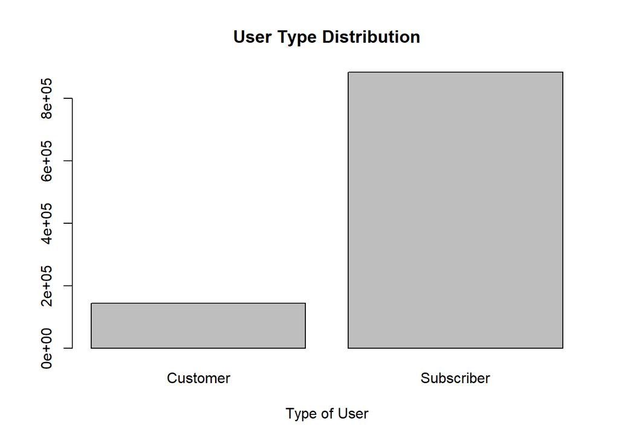

```r
# Barplot of number of subscribers vs customers

subsVsCustomers <- table(usedDataset$usertype)

barplot(subsVsCustomers, main="User Type Distribution",
   xlab="Type of User")
```

### Part 2: Identifying Patterns

Is there any correlation between the average age of users and the length of the trips they take?

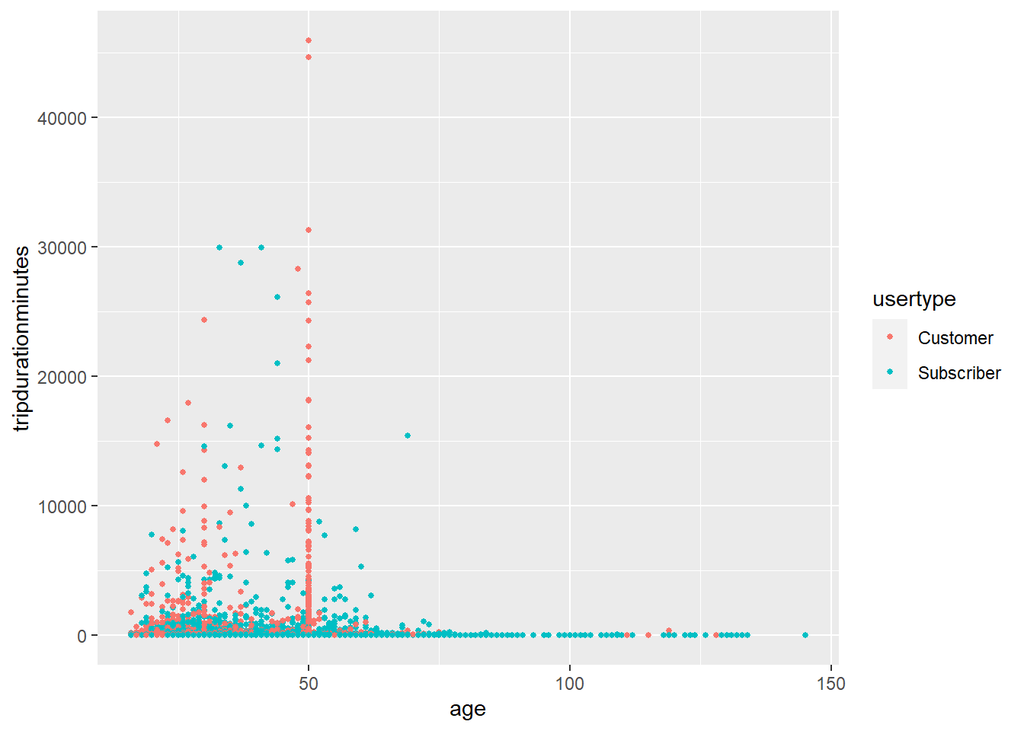

```r
# Create new column for age of user
usedDataset["age"] <- 2019 - usedDataset$birth.year

#Create new column for duration in minutes
usedDataset["tripdurationminutes"] <- usedDataset$tripduration/60

# Create Scatter Plot
ageVsTripLength <- ggplot(data=usedDataset, aes(x=age, y=tripdurationminutes, colour=usertype)) + geom_point(size=1, alpha=1)
ageVsTripLength
```

Here we can see that there is not really a correlation between age and length of trip. It is all very randomly distributed. Another interested observation is that there are points where people are over the age of 100. This is very unlikely, so these was most likely input errors on the user’s part. Another possible error is the trip durations, because some of the points show that some trips lasted tens of thousands of minutes. This could be because people fail to officially stop their ride, so the bike keeps counting up on its own even when the user is not using it.

What does the distribution of user ages look like?

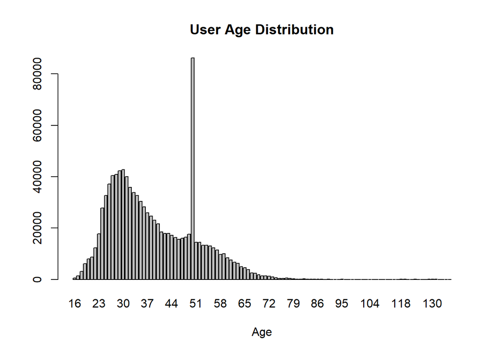

```r
ageDistribution <- table(usedDataset$age)

barplot(ageDistribution, main="User Age Distribution",
   xlab="Age")
```

If we look at the plot above, we can see that there is a weird outlier at around age 50. I am not sure why that is, but outside of that,it looks like the most common user is in their late twenties to early thirties. This makes sense, as NYC is a city with many young professionals.

Is there a strong correlation between trip duration and location displacement?

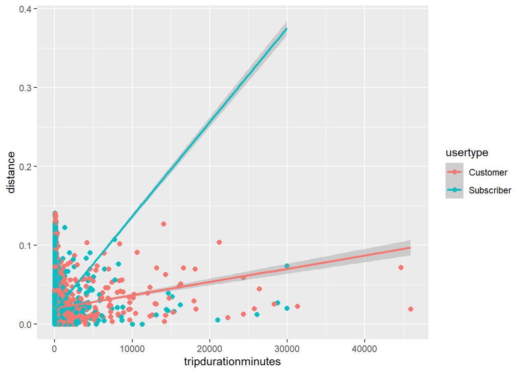

```r
# Create new column for displacement
usedDataset["distance"] <- sqrt(((usedDataset$end.station.latitude - usedDataset$start.station.latitude)^2) + ((usedDataset$end.station.longitude - usedDataset$start.station.longitude)^2))

# Create Scatter Plot
baseplotdisplacement <- ggplot(data=usedDataset, aes(x=tripdurationminutes, y=distance, colour=usertype)) + geom_point(size=2, alpha=1) + geom_smooth(method = "lm")
baseplotdisplacement
```

Here we can see that there is an overall positive correlation between distance displaced and the tripduration. However, this isn’t always necessarily the case. This is expected because displacement doesn’t equal total distance traveled, and it also doesn’t take different levels of traffic into account.